# Reevaluation of the Philips curve

Does higher inflation convey lower unemployment?

Dominik Gulácsy

02/01/2021

Abstract

This analysis is addressing the question whether the inverse relationship between unemployment and inflation stated by the Philips curve exists in modern economies. I use cross-sectional data on countries from 2017. After running several regression models, my results support that this inverse relationship does not hold for the present (2016-2018). This finding has relevance to appropiately evaluate policy decisions regarding unemployment and economic growth, and assess the overall health of the economy.

# Introduction

The main goal of this analysis is to test the Philips curve’s validity in current times. This economic theory was developed by [A. W. Phillips](https://onlinelibrary.wiley.com/doi/full/10.1111/j.1468-0335.1958.tb00003.x) stating that inflation and unemployment have a stable and inverse relationship. It was based on the idea that with economic growth comes inflation, which in turn should lead to more jobs and less unemployment. It sounds logical, however it was seriously called into question during the times of stagflation in the 1970’s. The major difference in case of this analysis is that by conducting a cross-sectional causal analysis I can get insight on whether the theory stands in global terms instead of checking it for one country throughout time.

# Data

Notes: 1. Removing observations with any missing values may make the sample less representative since usually smaller countries have missing values or those that are in turmoil. e.g: Venezuela

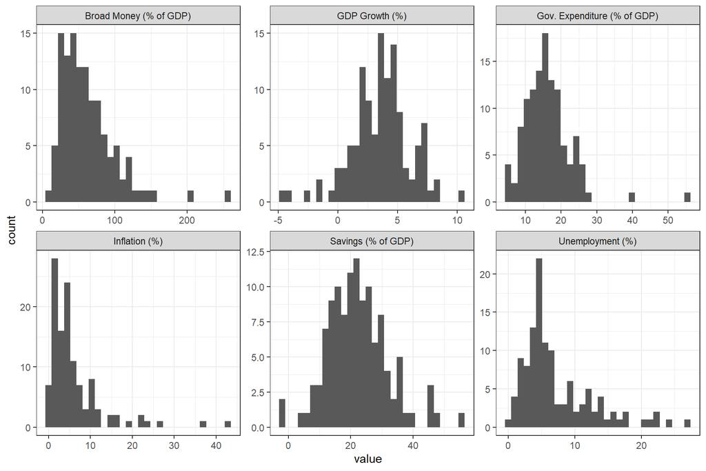

Figure 1: Histogram of variables (2017)

Table 1: Descriptive statistics of the variables (2017)

| statistics | Gov. Expenditure (% of GDP) | GDP Growth (%) | Broad Money (% of GDP) | Savings (% of GDP) | Inflation (%) | Unemployment (%) |
| --- | --- | --- | --- | --- | --- | --- |
| mean | 16.08 | 3.58 | 62.08 | 22.16 | 6.03 | 7.18 |
| median | 15.35 | 3.77 | 53.52 | 21.51 | 4.00 | 5.32 |
| min | 4.40 | -4.71 | 12.67 | -2.21 | 0.26 | 0.14 |
| max | 54.62 | 10.30 | 260.06 | 55.34 | 43.07 | 27.07 |
| 1st_qu. | 11.76 | 2.15 | 37.28 | 15.47 | 1.95 | 3.73 |
| 3rd_qu | 18.65 | 4.84 | 77.84 | 27.94 | 7.40 | 9.46 |
| sd | 6.62 | 2.49 | 37.85 | 9.68 | 6.75 | 5.47 |
| range | 50.22 | 15.01 | 247.39 | 57.54 | 42.81 | 26.93 |

# Appendix

## I. Model Specification

1. Investigate pattern of association for 2017 (LOESS charts)

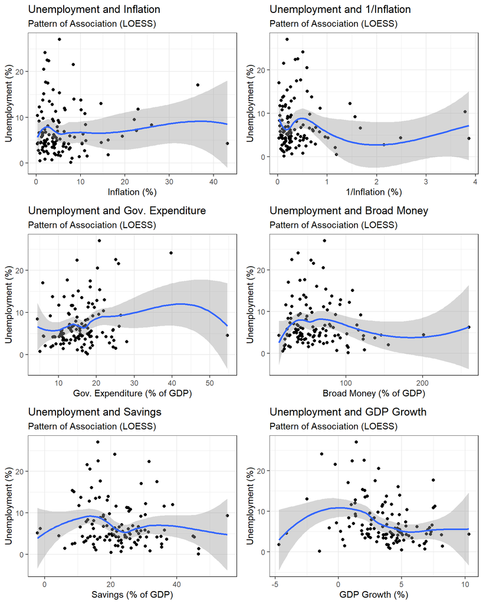

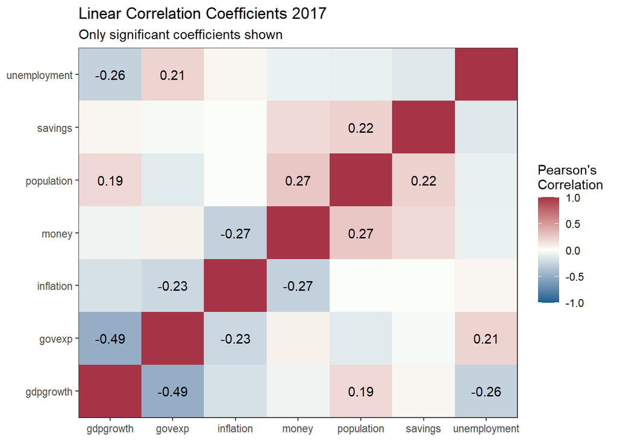

Figure 1: Corraltion matrix of variables (2017)

2. Model Comparison 2017

Analysis of the relatioship between unemployment and inflation. Data is for 2017 only.

|  | Unemployment rate (1) | Unemployment rate (2) | Unemployment rate (3) | Unemployment rate (4) | Unemployment rate (5) | Unemployment rate (6) | Unemployment rate (7)F | Unemployment rate (8)F |
| --- | --- | --- | --- | --- | --- | --- | --- | --- |
| intercept | 6.97*** | 7.30*** | 10.59*** | 6.51** | 1.79 | 2.95 | 4.46 | 5.28 |
|  | (0.71) | (0.60) | (1.43) | (2.10) | (3.23) | (3.78) | (3.36) | (2.78) |
| inflation | 0.03 |  | -0.00 | 0.06 | 0.08 | 0.05 | 0.03 |  |
|  | (0.08) |  | (0.07) | (0.07) | (0.07) | (0.08) | (0.07) |  |
| 1/inflation |  | -0.27 |  |  |  |  |  | 0.01 |
|  |  | (0.60) |  |  |  |  |  | (0.65) |
| GDP Growth (<0%) |  |  | 1.17 | 2.05* | 2.04* | 1.19 | 1.29 | 1.26 |
|  |  |  | (0.74) | (0.96) | (0.88) | (0.64) | (0.65) | (0.64) |
| GDP Growth (>=0%) |  |  | -0.87** | -0.69** | -0.70** | -0.82** | -0.85** | -0.86** |
|  |  |  | (0.27) | (0.25) | (0.25) | (0.27) | (0.26) | (0.26) |
| Gov. Exp. (<22%) |  |  |  | 0.20 | 0.16 |  |  |  |
|  |  |  |  | (0.11) | (0.12) |  |  |  |
| Gov. Exp. (>=22%) |  |  |  | 0.19 | 0.17 |  |  |  |
|  |  |  |  | (0.29) | (0.28) |  |  |  |
| Broad Money (<37%) |  |  |  |  | 0.17 | 0.19* | 0.19* | 0.17* |
|  |  |  |  |  | (0.09) | (0.09) | (0.08) | (0.08) |
| Broad Money (>=37%) |  |  |  |  | -0.02* | -0.02 | -0.03* | -0.03** |
|  |  |  |  |  | (0.01) | (0.01) | (0.01) | (0.01) |
| Savings (<15%) |  |  |  |  |  | 0.14 |  |  |
|  |  |  |  |  |  | (0.14) |  |  |
| Savings (>=15%) |  |  |  |  |  | -0.09 |  |  |
|  |  |  |  |  |  | (0.06) |  |  |
| R<sup>2</sup> | 0.00 | 0.00 | 0.11 | 0.14 | 0.17 | 0.16 | 0.15 | 0.15 |
| Adj. R<sup>2</sup> | -0.01 | -0.01 | 0.09 | 0.10 | 0.12 | 0.11 | 0.11 | 0.11 |
| Num. obs. | 118 | 118 | 118 | 118 | 118 | 118 | 118 | 118 |
| RMSE | 5.49 | 5.49 | 5.23 | 5.18 | 5.14 | 5.17 | 5.16 | 5.17 |

***p < 0.001; **p < 0.01; *p < 0.05

## III. Checking External Validity

1. Investigate pattern of association for 2016 (LOESS charts)

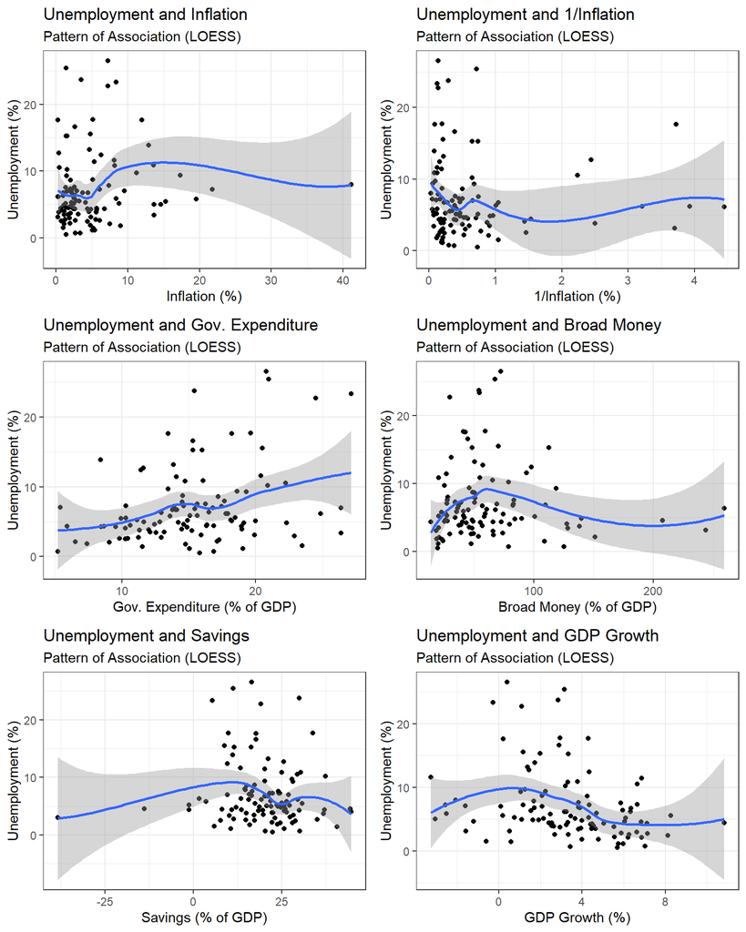

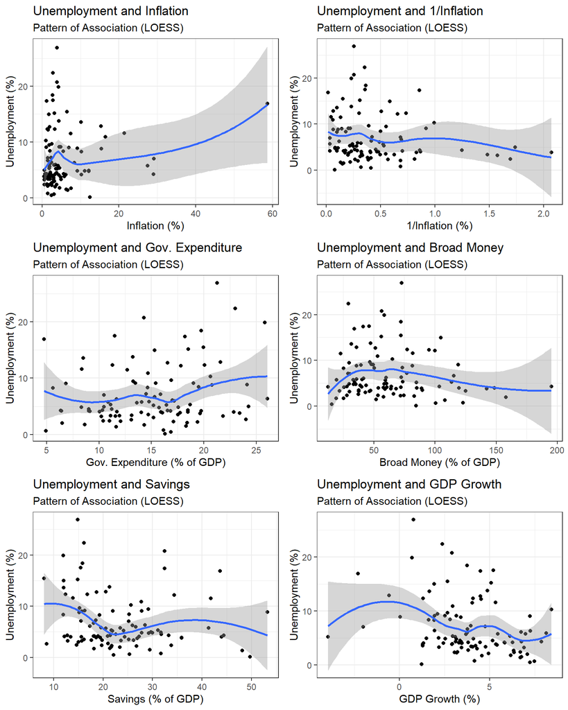